# Skyrim in numeri

## Analisi armature e armi di Skyrim

Adele Pioli, 163500

## Come mai?

E' un gioco a cui sono molto affezzionata, nonostante le varie partite giocate alcuni dati fondamentali non mi sono ancora del tutto chiari.  
Vorrei capire meglio le dinamiche del gioco anche analizzandone i dati.  
Per curiosità personale.

# Su cosa vorrei saperne di più?

Sono molto incuriosita dalla diversità sia fisica che comportamentale di ogni specie, vorrei puntare ad analizzarle meglio. Oltre alle razze anche la vastità delle armi e delle armature tra cui scegliere è molto interessante, vorrei analizzare le differenze in modo oggettivo, tramite i dati.

# Datasets usati nel progetto:

Fonte: kaggle  
Link: https://www.kaggle.com/datasets/elmartini/skyrim-weapons-dataset  
Autore: ElMartian  
Ultimo aggiornamento: 3 anni fa

|  | Name | Damage | Weight | Gold | Upgrade | Type | Category | Speed |
| --- | --- | --- | --- | --- | --- | --- | --- | --- |
| 0 | Ancient Nord Battle Axe | 18 | 22.0 | 28 | Steel Ingot | Battleaxe | Two-Handed | 0.7 |
| 1 | Daedric Battleaxe | 25 | 27.0 | 2750 | Ebony Ingot | Battleaxe | Two-Handed | 0.7 |
| 2 | Dragonbone Battleaxe | 26 | 30.0 | 3000 | Dragon Bone | Battleaxe | Two-Handed | 0.7 |
| 3 | Drainblood Battleaxe | 21 | 5.0 | 266 | None | Battleaxe | Two-Handed | 0.7 |
| 4 | Dwarven Battleaxe | 20 | 23.0 | 300 | Dwarven Metal Ingot | Battleaxe | Two-Handed | 0.7 |
| ... | ... | ... | ... | ... | ... | ... | ... | ... |
| 260 | Zephyr DG | 12 | 10.0 | 670 | Dwarven Metal Ingot | Bow | Archery | 1.0 |
| 281 | Crossbow | 19 | 14.0 | 120 | Steel Ingot | Crossbow | Archery | 1.0 |
| 282 | Dwarven Crossbow | 22 | 20.0 | 350 | Dwarven metal ingot | Crossbow | Archery | 1.0 |
| 283 | Enhanced Crossbow | 19 | 15.0 | 200 | Steel Ingot | Crossbow | Archery | 1.0 |
| 284 | Enhanced Dwarven Crossbow | 22 | 21.0 | 550 | Dwarven metal ingot | Crossbow | Archery | 1.0 |

263 rows × 8 columns

Fonte: kaggle  
Link: https://www.kaggle.com/datasets/stephenofarrell/skyrim-races-base-stats  
Autore: Ste_  
Ultimo aggiornamento: 5 anni fa

|  | Unnamed: 0 | Race | Smithing | Heavy Armor | Block | Two-Handed | One-Handed | Archery | Light Armor | Sneak | Lockpicking | Pickpocket | Speech | Alchemy | Illusion | Conjuration | Destruction | Restoration | Alteration | Enchanting |
| --- | --- | --- | --- | --- | --- | --- | --- | --- | --- | --- | --- | --- | --- | --- | --- | --- | --- | --- | --- | --- |
| 0 | 0 | Altmer (High Elf) | 15 | 15 | 15 | 15 | 15 | 15 | 15 | 15 | 15 | 15 | 15 | 15 | 25 | 20 | 20 | 20 | 20 | 20 |
| 1 | 1 | Argonian | 15 | 15 | 15 | 15 | 15 | 15 | 20 | 20 | 25 | 20 | 15 | 15 | 15 | 15 | 15 | 20 | 20 | 15 |
| 2 | 2 | Bosmer (Wood Elf) | 15 | 15 | 15 | 15 | 15 | 25 | 20 | 20 | 20 | 20 | 15 | 20 | 15 | 15 | 15 | 15 | 15 | 15 |
| 3 | 3 | Breton | 15 | 15 | 15 | 15 | 15 | 15 | 15 | 15 | 15 | 15 | 20 | 20 | 20 | 25 | 15 | 20 | 20 | 15 |
| 4 | 4 | Dunmer (Dark Elf) | 15 | 15 | 15 | 15 | 15 | 15 | 20 | 20 | 15 | 15 | 15 | 20 | 20 | 15 | 25 | 15 | 20 | 15 |
| 5 | 5 | Imperial | 15 | 20 | 20 | 15 | 20 | 15 | 15 | 15 | 15 | 15 | 15 | 15 | 15 | 15 | 20 | 25 | 15 | 20 |
| 6 | 6 | Khajiit | 15 | 15 | 15 | 15 | 20 | 20 | 15 | 25 | 20 | 20 | 15 | 20 | 15 | 15 | 15 | 15 | 15 | 15 |
| 7 | 7 | Nord | 20 | 15 | 20 | 25 | 20 | 15 | 20 | 15 | 15 | 15 | 20 | 15 | 15 | 15 | 15 | 15 | 15 | 15 |
| 8 | 8 | Orsimer (Orc) | 20 | 25 | 20 | 20 | 20 | 15 | 15 | 15 | 15 | 15 | 15 | 15 | 15 | 15 | 15 | 15 | 15 | 20 |
| 9 | 9 | Redguard | 20 | 15 | 20 | 15 | 25 | 20 | 15 | 15 | 15 | 15 | 15 | 15 | 15 | 15 | 20 | 15 | 20 | 15 |

Fonte: kaggle  
Link: https://www.kaggle.com/datasets/sc0v1n0/the-elder-scroll-skyrim-armor  
Autore: sc0v0ne  
Ultimo aggiornamento: 1 anno fa

|  | Name | Armor | Weight | Gold | Upgrade | Part | Type |
| --- | --- | --- | --- | --- | --- | --- | --- |
| 0 | Ahzidal's Gauntlets of Warding DR | 14.0 | 6.0 | 1750 | Steel Ingot | Gauntlets | Heavy |
| 1 | Ancient Nord Gauntlets | 10.0 | 4.0 | 25 | Iron Ingot | Gauntlets | Heavy |
| 2 | Blades Gauntlets | 13.0 | 8.0 | 85 | Steel Ingot | Gauntlets | Heavy |
| 3 | Bonemold Gauntlets DR | 12.0 | 3.5 | 60 | Bone Meal | Gauntlets | Heavy |
| 4 | Chitin Heavy Gauntlets DR | 14.0 | 5.0 | 135 | Chitin Plate | Gauntlets | Heavy |
| ... | ... | ... | ... | ... | ... | ... | ... |
| 270 | Volsung | 21.0 | 5.0 | 4611 | Corundum Ingot | Headrgear | Light |
| 271 | Winterhold Guard's Helmet | 11.0 | 2.0 | 35 | Iron Ingot | Headrgear | Light |
| 272 | Whiterun Guard's Helmet | 11.0 | 2.0 | 35 | Iron Ingot | Headrgear | Light |
| 273 | Wooden Mask | 1.0 | 2.0 | 51 | None | Headrgear | Light |
| 274 | Worn Shrouded Cowl | 8.0 | 2.0 | 50 | None | Headrgear | Light |

273 rows × 7 columns

## Tipi di armi presenti nel gioco

[figure not shown]

Waraxe

[figure not shown]

Bow

[figure not shown]

Crossbow

[figure not shown]

Dagger

[figure not shown]

Greatsword

[figure not shown]

Mace

[figure not shown]

Sword

[figure not shown]

Battle axe

[figure not shown]

Warhammer

## Tipi di armatura presenti nel gioco

[figure not shown]

## Razze presenti nel gioco:

[figure not shown]

Argonian

[figure not shown]

Breton

[figure not shown]

Dark elf

[figure not shown]

High elf

[figure not shown]

Imperial

[figure not shown]

Khajiti

[figure not shown]

Nord

[figure not shown]

Orc

[figure not shown]

Redguard

[figure not shown]

Wood elf

# Analisi della distribuzione dei vari oggetti nel gioco:

## Distribuzione delle tipologie di armi

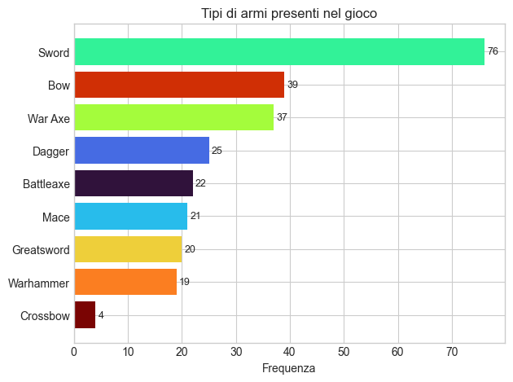

Sulle **263** armi presenti **solo** 4 sono balestre (crossbow), sono il **1,52%** del totale.  
Le spade (sword) ne costituiscono il **28,90%**.

## Distribuzione dei tipi di armi nelle categorie presenti

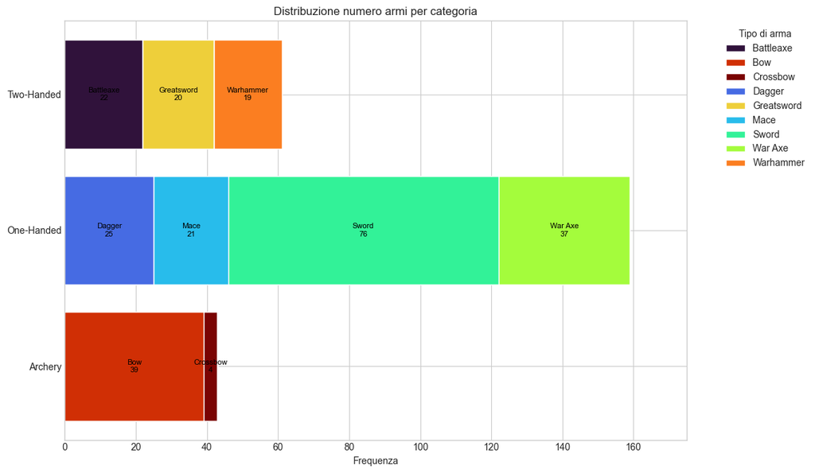

Le armi ad una mano (one-handed) sono il **60%** del totale delle armi presenti nel gioco.

## Distribuzione delle parti delle armature nei due tipi esistenti

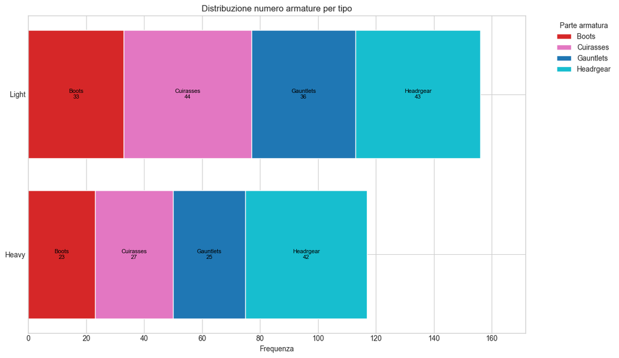

Su un totale di **273** armature, quelle *leggere* (light) sono **156**, il 57,14%.

# Analisi dei danni causati dalle armi

## Analizzo il danno medio rispetto alle tipologie presenti

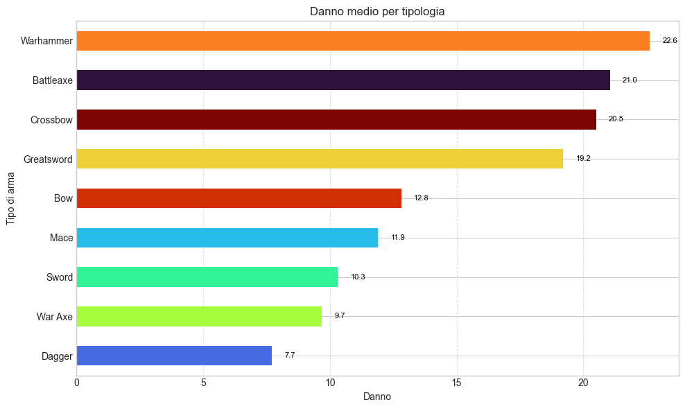

- Questo è **coerente** con il design tipico dei giochi RPG, armi più grandi è sinonimo di danni più alti.
- Gli archi (bow) e delle balestre (crossbow) hanno *punteggi alti* .
- Le armi a due mani (two-handed) fanno più danni, ma *non* sono le migliori.  
  **Analizziamo meglio.**

## Calcolo e analizzo le armi con i DPS migliori

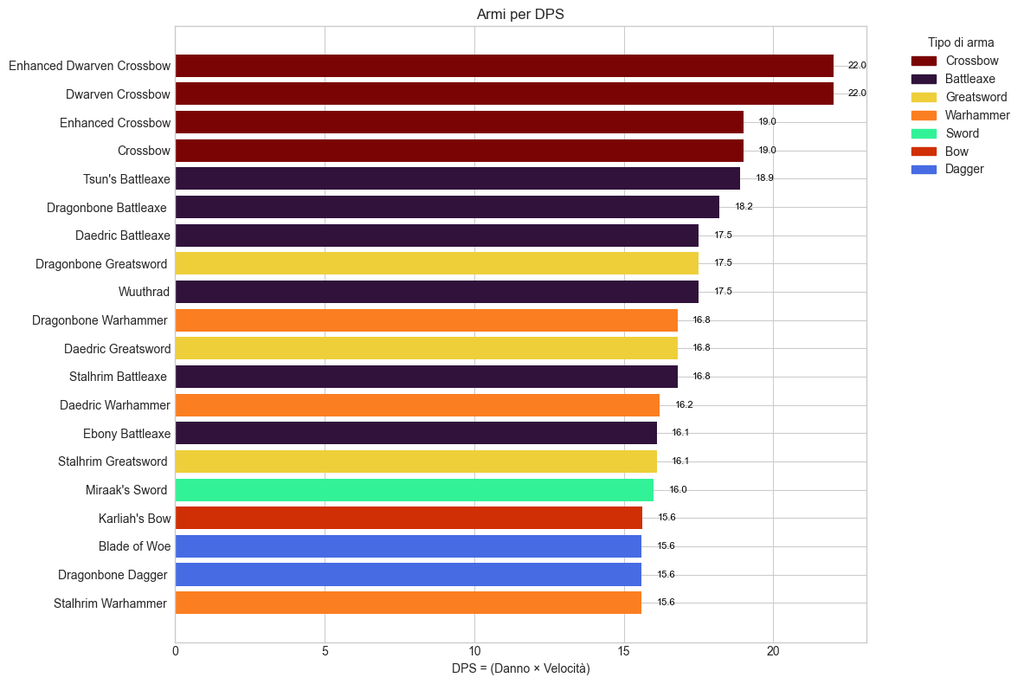

Le **balestre** (crossbow) hanno un DPS massimo di **22.0** DPS.  
Sono le armi con più DPS e sono anche le più rare.

## Considero il peso delle armi per vedere le più efficienti

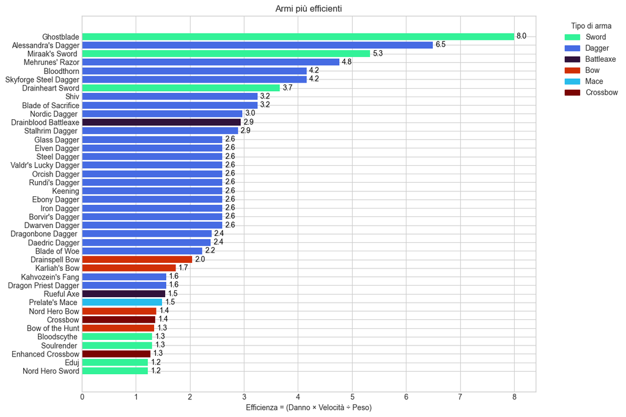

Le **armi a una mano** (one-handed) sono le più efficienti.  
Il peso molto ridotto rispetto alle altre categorie le porta in cima al grafico.  
La **ghostablade è una spada fantasma che pesa soltanto 1**, con un peso medio di 11.49.

## Considero la correlazione tra i tre valori analizzati

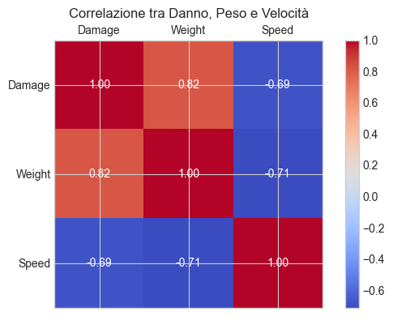

- Damage – Weight | +0.82 | Le armi più pesanti tendono a fare più danni.
- Damage – Speed | -0.69 | Le armi più veloci tendono a fare meno danni.
- Weight – Speed | -0.71 | Le armi più pesanti sono in genere più lente.

## Formula matematica per calcolare l'efficienza del danno

Damage = Round [(base damage + smithing increase) * (1 + skill/200) * (1 + perk effects) * (1 + item effects) * (1 + potion effect) * (1 + Seeker of Might bonus)]

## Ma noi utilizzeremo

Damage = (base damage) * (1 + skill/200)

Link info: https://en.uesp.net/wiki/Skyrim:Weapons

## Differenza dei danni per categoria rispetto alla razza usata

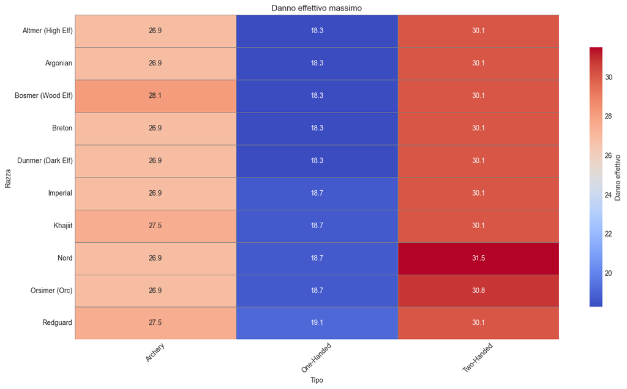

Consideriamo che:

- il danno base maggiore per gli *archi* (archery) è **25**
- il danno base maggiore per le *armi ad una mano* (one-handed) è **17**
- il danno base maggiore per le *armi a due mani* (two-handed) è **28**

# Analizzo le armature

## Analizziamo la protezione media dei vari tipi di armatura divise per parti

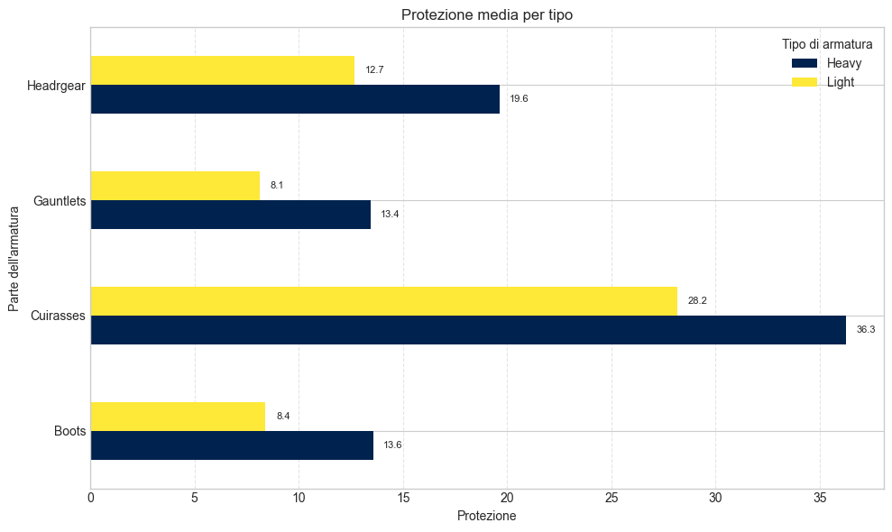

Gli **stivali** (boots) e i **guanti** (gauntlets) proteggono:

- **1/3** di quanto proteggono le corazze (cuirasses),
- **2/3** di quanto proteggono gli elmi (headrgear).

## Analizzo l'efficienza delle armature

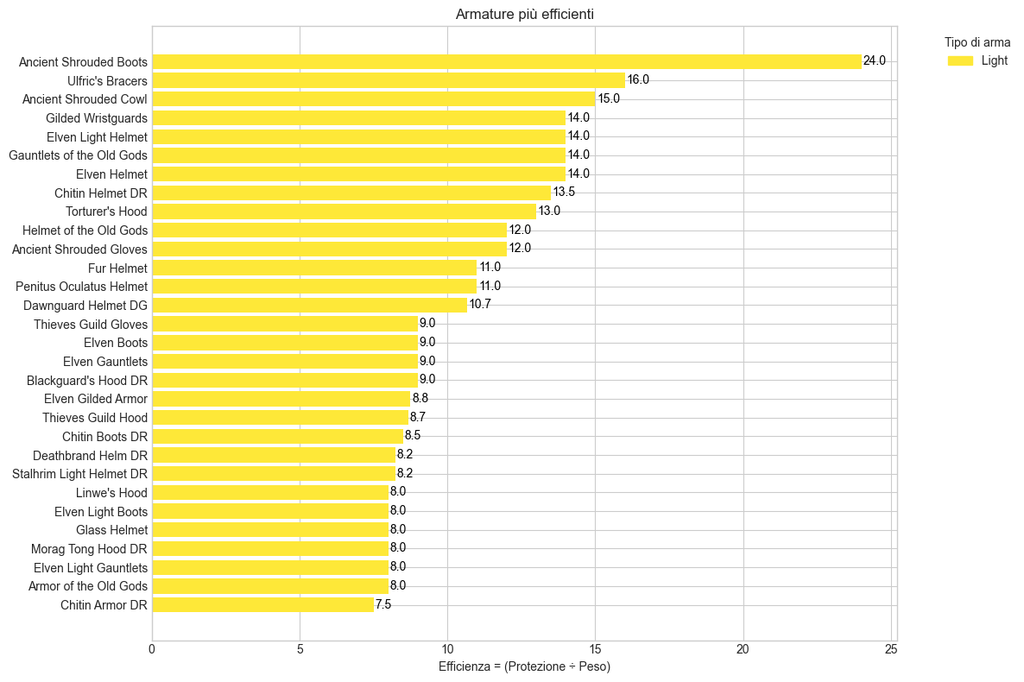

Ho limitato il grafico ai primi 30 pezzi perchè il **primo pezzo** di armatura **pesante** (heavy) che compare è il **numero 105**.

## Calcolo la protezione delle armature in relazione alle razze

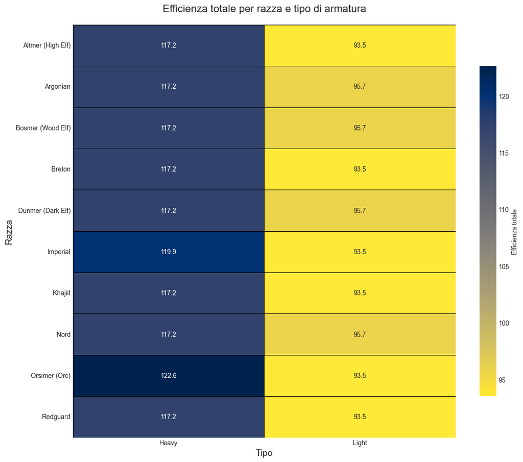

Consideriamo che:

- la protezione base maggiore per le armature *pesanti* (heavy) è **49.0**
- la protezione base maggiore per le armature *leggere* (light) è **41.0**

# Conclusioni

## Armature

- Le **armature leggere** (light) sono le più diffuse ma le meno protettive; risultano essere le più **efficienti**.
- Le **armature pesanti** (heavy) proteggono molto di più ma risultano meno leggere e più **ingombranti** nello zaino.